# Group of a set function

Manu

28 February 2017

## Definition of the fixed group of a function

Let $\mathcal{A}$ and $\mathcal{B}$ be finite sets. Let $f:\mathcal{A} \rightarrow \mathcal{B}$

We define $Fx(f) \in \mathrm{Aut(A)}$ as a subgroup of **Aut(A)** with the following property:

$$g \in Fx(f) \iff \forall a \in \mathcal{A}, f(g.a) = f(a)$$

Proof that **Fx(f)** is a subgroup of **Aut(A)**

> Let g1, g2 in **Fx(f)**. We want to show that $g1 \circ g2 \in Fx(f)$

> $$g1 \circ g2 \in Fx(f) \iff \forall a \in \mathcal{A}, f(g1 \circ g2(a)) = f(a)
> \iff f(g1 \circ g2(a)) = f(g2(a))$$

> Which is true since g1 is in **Fx(f)**

## Examples

1. $id:\{1, 2, 3\} \rightarrow \{1, 2, 3\}$
   $$g \in Fx(id) \iff \forall a \in \{1, 2, 3\}, id(g(a)) = id(a) \iff
   g(a) = a \iff g = e$$

   So Fx(id) = {e}

   This is the same for every injective function.
2. $c:\{1, 2, 3\} \rightarrow \{1\}$ Let g in Aut({1, 2, 3})
   $$g \in Fx(f) \iff \forall a \in \{1, 2, 3\}, f(g.a) = f(a) \iff 1 = 1$$
   So Fx(c) = S3
3. $f:\{1, 2, 3, 10, 11\} \rightarrow \{1, 10\}$  
   f:

   | 1 | 2 | 3 | 10 | 11 |
   | --- | --- | --- | --- | --- |
   | 1 | 1 | 1 | 10 | 10 |

   **Part 1**

   Let $g_1, h_1 \in Fx(f)_1$ let’s show that $g_1 \circ f_1 \in Fx(f)_1$. $g_1, h_1 \in Fx(f)$ so
   1. $\forall a \in \{1, 2, 3\}, g_1(a) \in \{1, 2, 3\}$
   2. $\forall a \in \{1, 2, 3\}, h_1(a) \in \{1, 2, 3\}$ Hence, $\forall a \in \{1, 2, 3\}, g_1(h_1(a)) \in \{1, 2, 3\}$ And $g_1 \circ f_1 \in Fx(f)_1$ Let’s show that $Fx(f)_1 \sim S3$. We need just show that
      $$\begin{array}{ll}
      \phi : S3 \rightarrow Fx(f)_1\\
      \phi(g)(x) = \left\{\begin{array}{ll}
      g(x), x \in \{1, 2, 3\}\\
      x, x \notin \{1, 2, 3\}
      \end{array}\right.
      \end{array}$$
      $\phi$ is an isomorphism. It is one because
      $$\phi(a) = \phi(b) \implies \forall x \in \{1, 2, 3\}, a(x) = b(x)$$
      So we have shown that Fx(f)_1 is isomorphic to S({1, 2, 3}). Similarly we show that Fx(f)_10 is isomorphic to S({10, 11}).

   **Part 2**

   We want to show that $Fx(f) = Fx(f)_1 \times Fx(f)_{10}$. For this we need to show that their intersection is {id}, that they commute and that they generate the whole group. If g belongs in $Fx(f)_1 \cap Fx(f)_{10}$ then g fixes element in {1, 2, 3} and elements in {10, 11} as well. So g must be the identity. Now let’s show that they commute. Let $g_1 \in Fx(f)_1, g_{10} \in Fx(f)_{10}$. Let $x \in \{1, 2, 3\}$ then $g_1(g_{10}(x)) = g_1(x)$. Similarly $g_{10}(g_1(x)) = g_1(x)$ since $g_1(x) \in \{1, 2, 3\}$. We show similarly that they commute for x in {10, 11}. So we have shown the commutativity. Now we shown that for any $g \in Fx(f)$ can be written as a product of the 2 groups. We let
   $$g_1(x) = \left\{\begin{array}{ll}
   g(x), x \in \{1, 2, 3\}\\
   x, x \notin \{1, 2, 3\}
   \end{array}\right.$$
   Similarly we define $g_{10}$. Let’s show that $g = g_1 \circ g_{10}$. Let $x \in \{1, 2, 3\}$ We have $g_{10}(x) = x$ so $g_1 \circ g_{10} (x) = g_1(x) = g(x)$ If $x \in \{10, 11\}$, $g_{10}(x) = g(x) \in \{10, 11\}$ so $g_1 \circ g_{10} (x) = g_{10}(x) = g(x)$.

   **Conclusion** We have shown that Fx(f) ~ S({1, 2, 3})xS({10, 11})

## Fixed group of any function

The goal of this part is to show that the fixed group of any function is equal to a direct product of permutation groups. More precisely the Fixed group is the direct product of the permutation groups of each equivalence class by the function. For this we will proceed like this:

1. We will prove the result for functions that have only one class of equivalence (constant functions)
2. We will define an operator that allows to build any function from constant function. More specifically, if we have $f: \mathcal{A} \rightarrow \mathcal{B}$ then we want to be able to write
   $$f = f_{|C_1} \sqcup f_{|C_2} \sqcup ... \sqcup f_{|C_n}$$
   Where $C_1, ... C_n$ are the distinct equivalence classes according to f.
3. We will show that for any 2 functions $Fx(f \sqcup g) = Fx(f) \times Fx(g)$

Together these 3 points will show the result.

### Part 1: Fixed group of a constant function

Let $f: \mathcal{A} \rightarrow \mathcal{B}$ be constant. Then Fx(f) = S(A).

Proof

> Since we already know that $Fx(f) \subseteq S(\mathcal{A})$ we need just show that $S(\mathcal{A}) \subseteq Fx(f)$ Let $g \in S(\mathcal{A})$, $\forall a \in \mathcal{A}, f(g(a)) = f(a)$ since f is constant. And $g \in Fx(f)$, so $S(\mathcal{A}) \subseteq Fx(f)$ and finally Fx(f) = S(A)

### Part 2: Disjoint union of functions $\sqcup$

Let $f_1: \mathcal{A_1} \rightarrow \mathcal{B_1}$ and $f_2: \mathcal{A_2} \rightarrow \mathcal{B_2}$ We assume $\mathcal{A_1} \cap \mathcal{A_2} = \emptyset$ and $\mathcal{B_1} \cap \mathcal{B2} = \emptyset$

We can define a function
$$f_1 \sqcup f_2: \mathcal{A_1} \sqcup \mathcal{A_2} \rightarrow
\mathcal{B_1} \sqcup \mathcal{B_2}$$

By
$$f_1 \sqcup f_2: x \mapsto \left\{\begin{array}{ll}
f_1(x), x \in \mathcal{A_1}\\
f_2(x), x \in \mathcal{A_2}
\end{array}\right.$$

### Part 3: $\mathrm{Fx}(f_1 \sqcup f_2)$

Throughout this part we pose: $f = f_1 \sqcup f_2$. In this part we need to show:

**Let’s go**

1. Let $g_1 \in \mathrm{Fx(f_1)}$, we write:

$$\forall x \in \mathcal{A_1} \cup \mathcal{A_2}, i_1(g_1)(x) \mapsto \left\{\begin{array}{ll}
g_1(x), x \in \mathcal{A_1}\\
x, x \in \mathcal{A_2}
\end{array}\right.$$

We show that $i_1$ is injective, that it’s image is in Fx(f) and that it is a group morphism. Let’s $x \in \mathcal{A_1}, f(i_1(g_1)(x)) = f(g_1(x)) = f_1(g_1(x)) = f_1(x) = f(x)$ Similarly for $x \in \mathcal{A_2}$ so we have proved that the image of $i_1$ is in Fx(f).

Let’s $g_1, g_2 \in \mathrm{Fx(f1)}$, $i_1(g_1) = i_1(g2) \implies \forall x \in \mathcal{A_1}, i_1(g_1)(x) = i_1(g_2)(x) \implies g_1(x) = g_2(x) \implies g_1 = g_2$ So $i_1 is injective$ and $\forall x \in \mathcal{A_1}, i_1(g_1 \circ g_2))(x) = g_1 \circ g2 (x) = g_1(g_2(x)) = g_1(i_1(g_2)(x)) = i_1(g_1) \circ i_1(g2) (x)$ We have the same equality for $x \in \mathcal{A_2}$ so we have shown that $i_1$ is a group homorphism.

Simlilarly we show that:
$$\forall x \in \mathcal{A_1} \cup \mathcal{A_2}, i_2(g_2)(x) \mapsto \left\{\begin{array}{ll}
x, x \in \mathcal{A_1}\\
g_2(x), x \in \mathcal{A_2}
\end{array}\right.$$

Is a group injection $\mathrm{Fx}(f_2) \rightarrow \mathrm{Fx}(f)$.

2. Now we want to show that $i_1(\mathrm{Fx}(f_1)) \cap i_2(\mathrm{Fx}(f_2)) = \{e\}$. Let $g_1 \in \mathrm{Fx}(f_1), g_2 \in \mathrm{Fx}(f_2)$. We have
   $$i_1(g_1) = i_2(g_2) \implies \forall x \in \mathcal{A_1}, i_1(g_1)(x) = i_2(g_2)(x) \implies g_1(x) = x \implies g_1 = id_{|\mathcal{A_1}}$$
   Similarly $g_2 = id|{\mathcal{A_2}}$ and we have shown that: $i_1(\mathrm{Fx}(f_1)) \cap i_2(\mathrm{Fx}(f_2)) = \{e\}$

## The dad beat example

[Hear the dad beat here:](https://splice.com/sounds/beatmaker/113f4f7166b1)

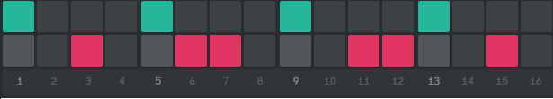

The dad beat

We can write the beat as a function $f: 1:16 \rightarrow {0, 1, 2}$ where 1, …, 16 represent the beat and {0, 1, 2} represent the instruments. We choose the following mapping for the instruments.

| Silence | Bass | Clap |
| --- | --- | --- |
| 0 | 1 | 2 |

And this is the function f:

| Beat | **1** | 2 | 3 | 4 | **5** | 6 | 7 | 8 | **9** | 10 | 11 | 12 | **13** | 14 | 15 | 16 |
| --- | --- | --- | --- | --- | --- | --- | --- | --- | --- | --- | --- | --- | --- | --- | --- | --- |
| f | 1 | 0 | 2 | 0 | 1 | 2 | 2 | 0 | 1 | 0 | 2 | 2 | 1 | 0 | 2 | 0 |

As we can see the classes by f are

| Element | Class |
| --- | --- |
| 0 | 2, 4, 8, 10, 14, 16 |
| 1 | 1, 5, 9, 13 |
| 2 | 3, 6, 7, 11, 12, 15 |

And according to the theorem we have $\mathrm{Fx(f)} = \mathrm{S\{2, 4, 8, 10, 14, 16\}} \times \mathrm{S\{1, 5, 9, 13\}} \times \mathrm{S\{3, 6, 7, 11, 12, 15\}}$

This group doesn’t seem to express much about the beat itself. For example we can exchange exchange the position of the first bass and put it in 2 and put the silence in 2 in 0. And we will get an isomorphic fixed group. But the beats will sound completely different! Basically the fixed group is uniquely determined by the number of each sounds, and not at all by their position. Said another way the fixed group fails to capture the idea of rhythm.